# Building and Explaining a Classifier using AutoMLx

by the Oracle AutoMLx Team

Classification Demo Notebook.

Copyright © 2025, Oracle and/or its affiliates.

Licensed under the Universal Permissive License v 1.0 as shown at https://oss.oracle.com/licenses/upl/

## Overview of this Notebook

In this notebook we will build a classifier using the Oracle AutoMLx tool for the public Census Income dataset. The dataset is a binary classification dataset, and more details about the dataset can be found at https://archive.ics.uci.edu/ml/datasets/Adult. We explore the various options provided by the Oracle AutoMLx tool, allowing the user to exercise control over the AutoMLx training process. We then evaluate the different models trained by AutoMLx. Finally we provide an overview of the possibilities that Oracle AutoMLx offers for explaining the predictions of the tuned model.

## Prerequisites

- Experience level: Novice (Python and Machine Learning)
- Professional experience: Some industry experience

## Business Use

Data analytics and modeling problems using Machine Learning (ML) are becoming popular and often rely on data science expertise to build accurate ML models. Such modeling tasks primarily involve the following steps:

- Preprocess dataset (clean, impute, engineer features, normalize).
- Pick an appropriate model for the given dataset and prediction task at hand.
- Tune the chosen model’s hyperparameters for the given dataset.

All of these steps are significantly time consuming and heavily rely on data scientist expertise. Unfortunately, to make this problem harder, the best feature subset, model, and hyperparameter choice widely varies with the dataset and the prediction task. Hence, there is no one-size-fits-all solution to achieve reasonably good model performance. Using a simple Python API, AutoML can quickly jump-start the datascience process with an accurately-tuned model and appropriate features for a given prediction task.

- Setup
- Load the Census Income dataset
- AutoML
  - Setting the execution engine
  - Create an Instance of Oracle AutoMLx
  - Train a Model using AutoMLx
  - Analyze the AutoMLx optimization process
    - Algorithm Selection
    - Adaptive Sampling
    - Feature Selection
    - Hyperparameter Tuning
    - Confusion Matrix
  - Advanced AutoMLx Configuration
- Machine Learning Explainability (MLX)
  - Initialize an MLExplainer
  - Model Explanations (Global Feature Importance)
  - Feature Dependence Explanations (PDP + ICE)
  - Prediction Explanations (Local Feature Importance)
    - Aggregate Local Feature Importance
  - Interactive What-If Explainers
  - Counterfactual Explanations
  - Advanced Feature Importance Options
    - Configure prediction explanation
    - Explain the model or explain the world
  - Advanced Feature Dependence Options (ALE)
- References

## Setup

Basic setup for the Notebook.

```python
%matplotlib inline
%load_ext autoreload
%autoreload 2
```

Load the required modules.

```python
import pandas as pd
import numpy as np
import matplotlib.pyplot as plt
import plotly.express as px
import plotly.figure_factory as ff
from sklearn.metrics import roc_auc_score, confusion_matrix
from sklearn.linear_model import LogisticRegression
from sklearn.compose import make_column_selector as selector
from sklearn.impute import SimpleImputer
from sklearn.preprocessing import StandardScaler, OneHotEncoder
from sklearn.compose import ColumnTransformer
from sklearn.pipeline import Pipeline
from sklearn.datasets import fetch_openml
from sklearn.model_selection import train_test_split
from sklearn.pipeline import Pipeline
from sklearn.impute import SimpleImputer
from sklearn.preprocessing import StandardScaler, OneHotEncoder
from sklearn.compose import ColumnTransformer
from sklearn.linear_model import LogisticRegression
from sklearn.compose import make_column_selector as selector
import time
import datetime
# Settings for plots
plt.rcParams['figure.figsize'] = [10, 7]
plt.rcParams['font.size'] = 15

import automlx
from automlx import init
```

## Load the Census Income dataset

We start by reading in the dataset from OpenML.

```python
dataset = fetch_openml(name='adult',version=1, as_frame=True)
df, y = dataset.data, dataset.target
```

Lets look at a few of the values in the data

```python
df.head()
```

|  | age | workclass | fnlwgt | education | education-num | marital-status | occupation | relationship | race | sex | capitalgain | capitalloss | hoursperweek | native-country |
| --- | --- | --- | --- | --- | --- | --- | --- | --- | --- | --- | --- | --- | --- | --- |
| 0 | 2 | State-gov | 77516.0 | Bachelors | 13.0 | Never-married | Adm-clerical | Not-in-family | White | Male | 1 | 0 | 2 | United-States |
| 1 | 3 | Self-emp-not-inc | 83311.0 | Bachelors | 13.0 | Married-civ-spouse | Exec-managerial | Husband | White | Male | 0 | 0 | 0 | United-States |
| 2 | 2 | Private | 215646.0 | HS-grad | 9.0 | Divorced | Handlers-cleaners | Not-in-family | White | Male | 0 | 0 | 2 | United-States |
| 3 | 3 | Private | 234721.0 | 11th | 7.0 | Married-civ-spouse | Handlers-cleaners | Husband | Black | Male | 0 | 0 | 2 | United-States |
| 4 | 1 | Private | 338409.0 | Bachelors | 13.0 | Married-civ-spouse | Prof-specialty | Wife | Black | Female | 0 | 0 | 2 | Cuba |

The Adult dataset contains a mix of numerical and string data, making it a challenging problem to train machine learning models on.

```python
pd.DataFrame({'Data type': df.dtypes}).T
```

|  | age | workclass | fnlwgt | education | education-num | marital-status | occupation | relationship | race | sex | capitalgain | capitalloss | hoursperweek | native-country |
| --- | --- | --- | --- | --- | --- | --- | --- | --- | --- | --- | --- | --- | --- | --- |
| Data type | category | category | float64 | category | float64 | category | category | category | category | category | category | category | category | category |

The dataset also contains a lot of missing values. The Oracle AutoMLx solution automatically handles missing values by dropping features with too many missing values, and filling in the remaining missing values based on the feature type.

```python
pd.DataFrame({'% missing values': df.isnull().sum() * 100 / len(df)}).T
```

|  | age | workclass | fnlwgt | education | education-num | marital-status | occupation | relationship | race | sex | capitalgain | capitalloss | hoursperweek | native-country |
| --- | --- | --- | --- | --- | --- | --- | --- | --- | --- | --- | --- | --- | --- | --- |
| % missing values | 0.0 | 5.730724 | 0.0 | 0.0 | 0.0 | 0.0 | 5.751198 | 0.0 | 0.0 | 0.0 | 0.0 | 0.0 | 0.0 | 1.754637 |

We visualize the distribution of the target variable in the training data.

```python
y_df = pd.DataFrame(y)
y_df.columns = ['income']

fig = px.histogram(y_df, x="income")
fig.show()
```

[interactive chart not shown]

We now separate the predictions (`y`) from the training data (`X`) for both the training (70%) and test (30%) datasets. The training set will be used to create a Machine Learning model using AutoMLx, and the test set will be used to evaluate the model's performance on unseen data.

```python
# Several of the columns are incorrectly labeled as category type in the original dataset
numeric_columns = ['age', 'capitalgain', 'capitalloss', 'hoursperweek']
for col in df.columns:
    if col in numeric_columns:
        df[col] = df[col].astype(int)


X_train, X_test, y_train, y_test = train_test_split(df,
                                                    y.map({'>50K': 1, '<=50K': 0}).astype(int),
                                                    train_size=0.7,
                                                    random_state=0)

X_train.shape, X_test.shape
```

```
((34189, 14), (14653, 14))
```

## AutoML

### Setting the execution engine

The AutoMLx package offers the function `init`, which allows to initialize the parallelization engine.

```python
init(engine='ray')
```

```
[2025-04-25 03:05:06,718] [automlx.backend] Overwriting ray session directory to /tmp/n4cg234n/ray, which will be deleted at engine shutdown. If you wish to retain ray logs, provide _temp_dir in ray_setup dict of engine_opts when initializing the AutoMLx engine.
```

### Create an instance of Oracle AutoMLx

The Oracle AutoMLx solution provides a pipeline that automatically finds a tuned model given a prediction task and a training dataset. In particular it allows to find a tuned model for any supervised prediction task, for example, classification or regression where the target can be binary, categorical or real-valued.

AutoML consists of five main steps:

- **Preprocessing** : Clean, impute, engineer, and normalize features.
- **Algorithm Selection** : Identify the right classification algorithm -in this notebook- for a given dataset, choosing from amongst:
  - AdaBoostClassifier
  - CatBoostClassifier
  - DecisionTreeClassifier
  - ExtraTreesClassifier
  - TorchMLPClassifier
  - KNeighborsClassifier
  - LGBMClassifier
  - LinearSVC
  - LogisticRegression
  - RandomForestClassifier
  - SVC
  - XGBClassifier
  - GaussianNB
  - TabNetClassifier
- **Adaptive Sampling** : Select a subset of the data samples for the model to be trained on.
- **Feature Selection** : Select a subset of the data features, based on the previously selected model.
- **Hyperparameter Tuning** : Find the right model parameters that maximize score for the given dataset.

All these pieces are readily combined into a simple AutoMLx pipeline which automates the entire Machine Learning process with minimal user input/interaction.

### Train a model using AutoMLx

The AutoMLx API is quite simple to work with. We create an instance of the pipeline. Next, the training data is passed to the `fit()` function which executes the previously mentioned steps.

```python
est1 = automlx.Pipeline()
est1.fit(X_train, y_train)
```

```
[2025-04-25 03:05:12,061] [automlx.interface] Dataset shape: (34189,14)
[2025-04-25 03:05:19,855] [sanerec.autotuning.parameter] Hyperparameter epsilon autotune range is set to its validation range. This could lead to long training times
[2025-04-25 03:05:21,017] [sanerec.autotuning.parameter] Hyperparameter repeat_quality_threshold autotune range is set to its validation range. This could lead to long training times
[2025-04-25 03:05:21,041] [sanerec.autotuning.parameter] Hyperparameter scope autotune range is set to its validation range. This could lead to long training times
[2025-04-25 03:05:21,155] [automlx.data_transform] Running preprocessing. Number of features: 15
[2025-04-25 03:05:21,812] [automlx.data_transform] Preprocessing completed. Took 0.657 secs
[2025-04-25 03:05:21,854] [automlx.process] Running Model Generation
[2025-04-25 03:05:21,909] [automlx.process] KNeighborsClassifier is disabled. The KNeighborsClassifier model is only recommended for datasets with less than 10000 samples and 1000 features.
[2025-04-25 03:05:21,909] [automlx.process] SVC is disabled. The SVC model is only recommended for datasets with less than 10000 samples and 1000 features.
[2025-04-25 03:05:21,911] [automlx.process] Model Generation completed.
[2025-04-25 03:05:21,985] [automlx.model_selection] Running Model Selection
[2025-04-25 03:05:53,108] [automlx.model_selection] Model Selection completed - Took 31.123 sec - Selected models: [['XGBClassifier']]
[2025-04-25 03:05:53,134] [automlx.adaptive_sampling] Running Adaptive Sampling. Dataset shape: (34189,16).
[2025-04-25 03:05:55,173] [automlx.trials] Adaptive Sampling completed - Took 2.0383 sec.
[2025-04-25 03:05:55,267] [automlx.feature_selection] Starting feature ranking for XGBClassifier
[2025-04-25 03:06:03,981] [automlx.feature_selection] Feature Selection completed. Took 8.730 secs.
[2025-04-25 03:06:04,028] [automlx.trials] Running Model Tuning for ['XGBClassifier']
[2025-04-25 03:06:47,769] [automlx.trials] Best parameters for XGBClassifier: {'learning_rate': 0.10242113515453982, 'min_child_weight': 2, 'max_depth': 4, 'reg_alpha': 0.0007113117640155693, 'booster': 'gbtree', 'reg_lambda': 1.001, 'n_estimators': 141, 'use_label_encoder': False}
[2025-04-25 03:06:47,770] [automlx.trials] Model Tuning completed. Took: 43.742 secs
[2025-04-25 03:06:54,215] [automlx.interface] Re-fitting pipeline
[2025-04-25 03:06:54,230] [automlx.final_fit] Skipping updating parameter seed, already fixed by FinalFit_806b0073-0
[2025-04-25 03:06:56,578] [automlx.interface] AutoMLx completed.
```

```
<automlx._interface.classifier.AutoClassifier at 0x151aab3c6d00>
```

A model is then generated (`est1`) and can be used for prediction tasks. We use the `roc_auc_score` scoring metric to evaluate the performance of this model on unseen data (`X_test`).

```python
y_proba = est1.predict_proba(X_test)
score_default = roc_auc_score(y_test, y_proba[:, 1])

print(f'Score on test data : {score_default}')
```

```
Score on test data : 0.9140858492615117
```

### Analyze the AutoMLx optimization process

During the AutoMLx process, a summary of the optimization process is logged. It consists of:

- Information about the training data .
- Information about the AutoMLx Pipeline, such as:
  - Selected features that AutoMLx found to be most predictive in the training data;
  - Selected algorithm that was the best choice for this data;
  - Selected hyperparameters for the selected algorithm.

AutoMLx provides a `print_summary` API to output all the different trials performed.

```python
est1.print_summary()
```

General Summary

| (34189, 14) |
| --- |
| None |
| KFoldSplit(Shuffle=True, Seed=7, folds=5, stratify by=target) |
| neg_log_loss |
| XGBClassifier |
| {'learning_rate': 0.10242113515453982, 'min_child_weight': 2, 'max_depth': 4, 'reg_alpha': 0.0007113117640155693, 'booster': 'gbtree', 'reg_lambda': 1.001, 'n_estimators': 141, 'use_label_encoder': Fa… |
| 25.2.1 |
| 3.9.21 (main, Dec 11 2024, 16:24:11) \n[GCC 11.2.0] |

Trials Summary

| Step | # Samples | # Features | Algorithm | Hyperparameters | Score (neg_log_loss) | All Metrics | Runtime (Seconds) | Memory Usage (GB) | Finished |
| --- | --- | --- | --- | --- | --- | --- | --- | --- | --- |
| Model Selection | {1: 4000, 2: 4000, 3: 4000, 5: 4000, 4: 4000} | 15 | XGBClassifier | {'learning_rate': 0.1, 'min_child_weight': 1, 'max_depth': 3, 'reg_alpha': 0, 'booster': 'gbtree', 'reg_lambda': 1, 'n_estimators': 100, 'use_label_encoder': False} | -0.3813 | {'neg_log_loss': -0.38129734602336923} | 1.1177 | 0.3214 | Fri Apr 25 03:05:43 2025 |
| Model Selection | {2: 4000, 5: 4000, 1: 4000, 3: 4000, 4: 4000} | 15 | CatBoostClassifier | {'iterations': 235, 'learning_rate': 0.787168, 'leaf_estimation_method': 'Newton', 'colsample_bylevel': 0.096865, 'depth': 3, 'l2_leaf_reg': 2.567326, 'feature_border_type': 'UniformAndQuantiles', 'mo… | -0.3881 | {'neg_log_loss': -0.38808832474759763} | 10.8342 | 0.3193 | Fri Apr 25 03:05:42 2025 |
| Model Selection | {3: 4000, 1: 4000, 5: 4000, 4: 4000, 2: 4000} | 15 | LGBMClassifier | {'num_leaves': 31, 'boosting_type': 'gbdt', 'learning_rate': 0.1, 'min_child_weight': 0.001, 'max_depth': -1, 'reg_alpha': 0, 'reg_lambda': 1, 'n_estimators': 100, 'class_weight': 'balanced'} | -0.3898 | {'neg_log_loss': -0.38980519262954033} | 12.8814 | 0.3083 | Fri Apr 25 03:05:43 2025 |
| Model Selection | {1: 4000, 5: 4000, 3: 4000, 4: 4000, 2: 4000} | 15 | LogisticRegressionClassifier | {'C': 1.0, 'solver': 'liblinear', 'class_weight': 'balanced'} | -0.3908 | {'neg_log_loss': -0.3907935186356912} | 0.6874 | 0.3279 | Fri Apr 25 03:05:43 2025 |
| Model Selection | {1: 4000, 2: 4000, 3: 4000, 4: 4000, 5: 4000} | 15 | RandomForestClassifier | {'n_estimators': 100, 'min_samples_split': 0.00125, 'min_samples_leaf': 0.000625, 'max_features': 0.777777778, 'class_weight': 'balanced'} | -0.4093 | {'neg_log_loss': -0.40930045927988684} | 2.7773 | 0.2950 | Fri Apr 25 03:05:43 2025 |
| Model Selection | {2: 4000, 1: 4000, 3: 4000, 4: 4000, 5: 4000} | 15 | ExtraTreesClassifier | {'n_estimators': 100, 'min_samples_split': 0.00125, 'min_samples_leaf': 0.000625, 'max_features': 0.777777778, 'class_weight': 'balanced', 'criterion': 'gini'} | -0.4196 | {'neg_log_loss': -0.4196315514455088} | 3.1310 | 0.2772 | Fri Apr 25 03:05:41 2025 |
| Model Selection | {3: 4000, 5: 4000, 4: 4000, 2: 4000, 1: 4000} | 15 | TorchMLPClassifier | {'optimizer_class': 'Adam', 'shuffle_dataset_each_epoch': True, 'optimizer_params': {}, 'criterion_class': None, 'criterion_params': {}, 'scheduler_class': None, 'scheduler_params': {}, 'batch_size': … | -0.8294 | {'neg_log_loss': -0.8293741212177753} | 49.1100 | 0.6041 | Fri Apr 25 03:05:52 2025 |
| Model Selection | {1: 4000, 2: 4000, 3: 4000, 4: 4000, 5: 4000} | 15 | GaussianNB | {} | -1.0622 | {'neg_log_loss': -1.0622002049203993} | 0.3964 | 0.2871 | Fri Apr 25 03:05:41 2025 |
| Model Selection | {4: 4000, 3: 4000, 1: 4000, 2: 4000, 5: 4000} | 15 | DecisionTreeClassifier | {'min_samples_split': 0.00125, 'min_samples_leaf': 0.000625, 'max_features': 1.0, 'class_weight': None} | -4.6323 | {'neg_log_loss': -4.632288461805368} | 1.3565 | 0.2737 | Fri Apr 25 03:05:41 2025 |
| Adaptive Sampling | {1: 15493, 2: 15493, 3: 15493, 4: 15493, 5: 15494} | 15 | AdaptiveSamplingStage_XGBClassifier | {'learning_rate': 0.1, 'min_child_weight': 1, 'max_depth': 3, 'reg_alpha': 0, 'booster': 'gbtree', 'reg_lambda': 1, 'n_estimators': 100, 'use_label_encoder': False} | -0.349 | {'neg_log_loss': -0.3490238812123456} | 3.3692 | 0.6036 | Fri Apr 25 03:05:54 2025 |
| ... | ... | ... | ... | ... | ... | ... | ... | ... | ... |
| Model Tuning | {1: 12222, 2: 12222, 3: 12222, 4: 12223, 5: 12223} | 15 | XGBClassifier | {'learning_rate': 0.0001, 'min_child_weight': 0, 'max_depth': 2, 'reg_alpha': 0.0007113117640155693, 'booster': 'gbtree', 'reg_lambda': 0, 'n_estimators': 50, 'use_label_encoder': False} | -0.6912 | {'neg_log_loss': -0.6911964137047958} | 1.2147 | 0.6153 | Fri Apr 25 03:06:19 2025 |
| Model Tuning | {1: 12222, 2: 12222, 3: 12222, 4: 12223, 5: 12223} | 15 | XGBClassifier | {'learning_rate': 0.0001, 'min_child_weight': 0, 'max_depth': 2, 'reg_alpha': 0.0007513117640155693, 'booster': 'gbtree', 'reg_lambda': 0, 'n_estimators': 50, 'use_label_encoder': False} | -0.6912 | {'neg_log_loss': -0.6911964137047958} | 1.2364 | 0.6092 | Fri Apr 25 03:06:20 2025 |
| Model Tuning | {1: 12222, 2: 12222, 3: 12222, 4: 12223, 5: 12223} | 15 | XGBClassifier | {'learning_rate': 0.0001, 'min_child_weight': 0, 'max_depth': 2, 'reg_alpha': 0, 'booster': 'gbtree', 'reg_lambda': 0.01778279410038923, 'n_estimators': 50, 'use_label_encoder': False} | -0.6912 | {'neg_log_loss': -0.6911964480070908} | 1.1856 | 0.6153 | Fri Apr 25 03:06:20 2025 |
| Model Tuning | {1: 12222, 2: 12222, 3: 12222, 4: 12223, 5: 12223} | 15 | XGBClassifier | {'learning_rate': 0.0001, 'min_child_weight': 0, 'max_depth': 2, 'reg_alpha': 0, 'booster': 'gbtree', 'reg_lambda': 0.01878279410038923, 'n_estimators': 50, 'use_label_encoder': False} | -0.6912 | {'neg_log_loss': -0.6911964560751593} | 1.1809 | 0.6098 | Fri Apr 25 03:06:20 2025 |
| Model Tuning | {1: 12222, 2: 12222, 3: 12222, 4: 12223, 5: 12223} | 15 | XGBClassifier | {'learning_rate': 0.0001, 'min_child_weight': 0, 'max_depth': 2, 'reg_alpha': 0.2249365300761397, 'booster': 'gbtree', 'reg_lambda': 0, 'n_estimators': 50, 'use_label_encoder': False} | -0.6912 | {'neg_log_loss': -0.6911968446197632} | 1.2241 | 0.6153 | Fri Apr 25 03:06:20 2025 |
| Model Tuning | {1: 12222, 2: 12222, 3: 12222, 4: 12223, 5: 12223} | 15 | XGBClassifier | {'learning_rate': 0.0001, 'min_child_weight': 0, 'max_depth': 2, 'reg_alpha': 0.2249765300761397, 'booster': 'gbtree', 'reg_lambda': 0, 'n_estimators': 50, 'use_label_encoder': False} | -0.6912 | {'neg_log_loss': -0.6911968446197632} | 1.1658 | 0.6098 | Fri Apr 25 03:06:20 2025 |
| Model Tuning | {1: 12222, 2: 12222, 3: 12222, 4: 12223, 5: 12223} | 15 | XGBClassifier | {'learning_rate': 0.0001, 'min_child_weight': 0, 'max_depth': 2, 'reg_alpha': 0, 'booster': 'gbtree', 'reg_lambda': 1, 'n_estimators': 50, 'use_label_encoder': False} | -0.6912 | {'neg_log_loss': -0.6911999162246485} | 1.2465 | 0.6134 | Fri Apr 25 03:06:20 2025 |
| Model Tuning | {1: 12222, 2: 12222, 3: 12222, 4: 12223, 5: 12223} | 15 | XGBClassifier | {'learning_rate': 0.0001, 'min_child_weight': 0, 'max_depth': 2, 'reg_alpha': 0, 'booster': 'gbtree', 'reg_lambda': 1.001, 'n_estimators': 50, 'use_label_encoder': False} | -0.6912 | {'neg_log_loss': -0.6911999174202924} | 1.2102 | 0.6153 | Fri Apr 25 03:06:20 2025 |
| Model Tuning | {1: 12222, 2: 12222, 3: 12222, 4: 12223, 5: 12223} | 15 | XGBClassifier | {'learning_rate': 0.0001, 'min_child_weight': 0, 'max_depth': 2, 'reg_alpha': 0, 'booster': 'gbtree', 'reg_lambda': 5.623413251903491, 'n_estimators': 50, 'use_label_encoder': False} | -0.6912 | {'neg_log_loss': -0.6912154271501312} | 1.1138 | 0.6098 | Fri Apr 25 03:06:21 2025 |
| Model Tuning | {1: 12222, 2: 12222, 3: 12222, 4: 12223, 5: 12223} | 15 | XGBClassifier | {'learning_rate': 0.0001, 'min_child_weight': 0, 'max_depth': 2, 'reg_alpha': 0, 'booster': 'gbtree', 'reg_lambda': 5.6244132519034915, 'n_estimators': 50, 'use_label_encoder': False} | -0.6912 | {'neg_log_loss': -0.691215428004673} | 1.2120 | 0.6153 | Fri Apr 25 03:06:21 2025 |

We also provide the capability to visualize the results of each stage of the AutoMLx pipeline.

#### Algorithm Selection

The plot below shows the scores predicted by Algorithm Selection for each algorithm. The horizontal line shows the average score across all algorithms. Algorithms below the line are colored turquoise, whereas those with a score higher than the mean are colored teal.

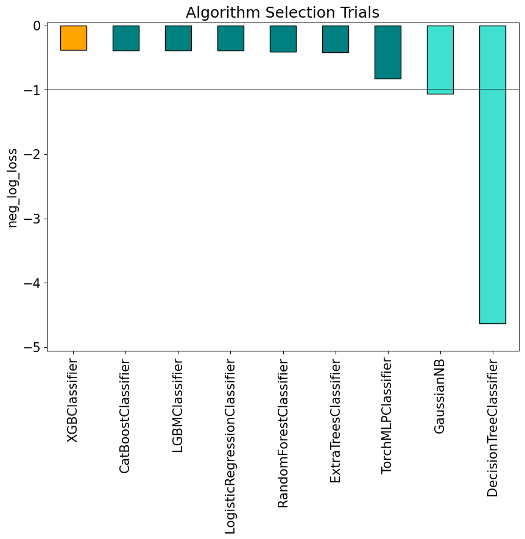

```python
# Each trial is a row in a dataframe that contains
# Algorithm, Number of Samples, Number of Features, Hyperparameters, Score, Runtime, Memory Usage, Step as features
trials = est1.completed_trials_summary_[est1.completed_trials_summary_["Step"].str.contains('Model Selection')]
name_of_score_column = f"Score ({est1._inferred_score_metric[0].name})"
trials.replace([np.inf, -np.inf], np.nan, inplace=True)
trials.dropna(subset=[name_of_score_column], inplace = True)
scores = trials[name_of_score_column].tolist()
models = trials['Algorithm'].tolist()
colors = []

y_margin = 0.10 * (max(scores) - min(scores))
s = pd.Series(scores, index=models).sort_values(ascending=False)
s = s.dropna()
for f in s.keys():
    if f.strip()  ==  est1.selected_model_.strip():
        colors.append('orange')
    elif s[f] >= s.mean():
        colors.append('teal')
    else:
        colors.append('turquoise')

fig, ax = plt.subplots(1)
ax.set_title("Algorithm Selection Trials")
ax.set_ylim(min(scores) - y_margin, max(scores) + y_margin)
ax.set_ylabel(est1._inferred_score_metric[0].name)
s.plot.bar(ax=ax, color=colors, edgecolor='black')
ax.axhline(y=s.mean(), color='black', linewidth=0.5)
plt.show()
```

#### Adaptive Sampling

Following Algorithm Selection, Adaptive Sampling aims to find the smallest dataset sample that can be created without compromising validation set score for the chosen model. This is used to speed up feature selection and tuning; however, the full dataset is still used to train the final model.

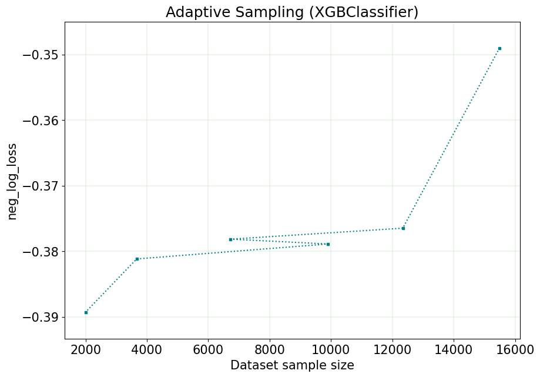

```python
# Each trial is a row in a dataframe that contains
# Algorithm, Number of Samples, Number of Features, Hyperparameters, Score, Runtime, Memory Usage, Step as features
trials = est1.completed_trials_summary_[est1.completed_trials_summary_["Step"].str.contains('Adaptive Sampling')]
trials.replace([np.inf, -np.inf], np.nan, inplace=True)
trials.dropna(subset=[name_of_score_column], inplace = True)
scores = trials[name_of_score_column].tolist()
n_samples = [int(sum(d.values()) / len(d)) if isinstance(d, dict) else d for d in trials['# Samples']]


y_margin = 0.10 * (max(scores) - min(scores))
fig, ax = plt.subplots(1)
ax.set_title("Adaptive Sampling ({})".format(est1.selected_model_))
ax.set_xlabel('Dataset sample size')
ax.set_ylabel(est1._inferred_score_metric[0].name)
ax.grid(color='g', linestyle='-', linewidth=0.1)
ax.set_ylim(min(scores) - y_margin, max(scores) + y_margin)
ax.plot(n_samples, scores, 'k:', marker="s", color='teal', markersize=3)
plt.show()
```

#### Feature Selection

After finding a sample subset, the next step is to find a relevant feature subset to maximize score for the chosen algorithm. AutoMLx Feature Selection follows an intelligent search strategy, looking at various possible feature rankings and subsets, and identifying that smallest feature subset that does not compromise on score for the chosen algorithm. The orange line shows the optimal number of features chosen by Feature Selection.

```
Features selected: ['age', 'capitalgain', 'capitalloss', 'education', 'education-num', 'fnlwgt', 'hoursperweek', 'marital-status', 'native-country', 'occupation', 'race', 'relationship', 'sex_1', 'sex_2', 'workclass']
Features dropped: []
```

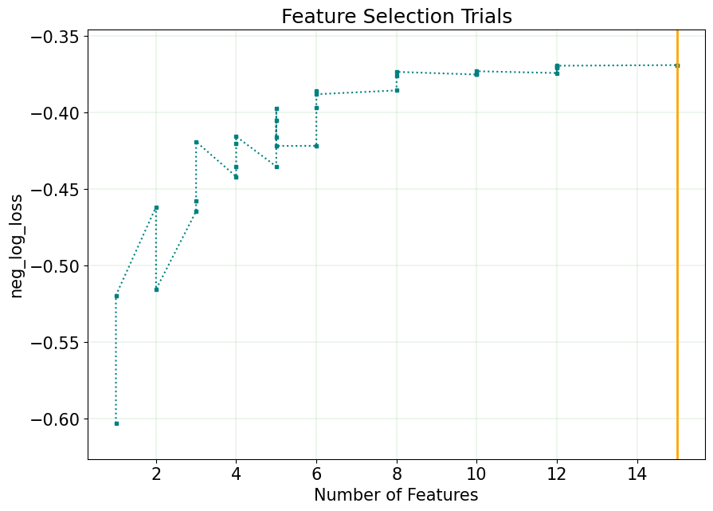

```python
print(f"Features selected: {est1.selected_features_names_}")
dropped_features = df.drop(est1.selected_features_names_raw_, axis=1).columns
print(f"Features dropped: {dropped_features.to_list()}")

# Each trial is a row in a dataframe that contains
# Algorithm, Number of Samples, Number of Features, Hyperparameters, Score, Runtime, Memory Usage, Step as features
trials = est1.completed_trials_summary_[est1.completed_trials_summary_["Step"].str.contains('Feature Selection')]
trials.replace([np.inf, -np.inf], np.nan, inplace=True)
trials.dropna(subset=[name_of_score_column], inplace = True)
trials.sort_values(by=['# Features'],ascending=True, inplace = True)
scores = trials[name_of_score_column].tolist()
n_features = trials['# Features'].tolist()

y_margin = 0.10 * (max(scores) - min(scores))
fig, ax = plt.subplots(1)
ax.set_title("Feature Selection Trials")
ax.set_xlabel("Number of Features")
ax.set_ylabel(est1._inferred_score_metric[0].name)
ax.grid(color='g', linestyle='-', linewidth=0.1)
ax.set_ylim(min(scores) - y_margin, max(scores) + y_margin)
ax.plot(n_features, scores, 'k:', marker="s", color='teal', markersize=3)
ax.axvline(x=len(est1.selected_features_names_), color='orange', linewidth=2.0)
plt.show()
```

#### Hyperparameter Tuning

Hyperparameter Tuning is the last stage of the AutoMLx pipeline, and focuses on improving the chosen algorithm's score on the reduced dataset (after Adaptive Sampling and Feature Selection). We use a novel algorithm to search across many hyperparameters dimensions, and converge automatically when optimal hyperparameters are identified. Each trial represents a particular hyperparameters configuration for the selected model.

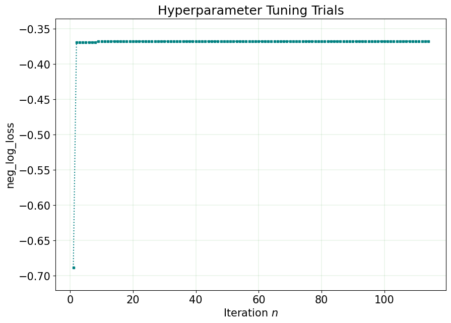

```python
# Each trial is a row in a dataframe that contains
# Algorithm, Number of Samples, Number of Features, Hyperparameters, Score, Runtime, Memory Usage, Step as features
trials = est1.completed_trials_summary_[est1.completed_trials_summary_["Step"].str.contains('Model Tuning')]
trials.replace([np.inf, -np.inf], np.nan, inplace=True)
trials.dropna(subset=[name_of_score_column], inplace = True)
trials.drop(trials[trials['Finished'] == -1].index, inplace = True)
trials['Finished']= trials['Finished'].apply(lambda x: time.mktime(datetime.datetime.strptime(x,
                                             "%a %b %d %H:%M:%S %Y").timetuple()))
trials.sort_values(by=['Finished'],ascending=True, inplace = True)
scores = trials[name_of_score_column].tolist()
score = []
score.append(scores[0])
for i in range(1,len(scores)):
    if scores[i]>= score[i-1]:
        score.append(scores[i])
    else:
        score.append(score[i-1])
y_margin = 0.10 * (max(score) - min(score))

fig, ax = plt.subplots(1)
ax.set_title("Hyperparameter Tuning Trials")
ax.set_xlabel("Iteration $n$")
ax.set_ylabel(est1._inferred_score_metric[0].name)
ax.grid(color='g', linestyle='-', linewidth=0.1)
ax.set_ylim(min(score) - y_margin, max(score) + y_margin)
ax.plot(range(1, len(trials) + 1), score, 'k:', marker="s", color='teal', markersize=3)
plt.show()
```

#### Confusion Matrix

We can use a Confusion Matrix to help us visualize the model's behavior. Note that the displayed confusion matrix represents percentages.

```python
y_pred = est1.predict(X_test)
cm = confusion_matrix(y_test.astype(int), y_pred, labels=[False, True])
cm = cm.astype('float') / cm.sum(axis=1)[:, np.newaxis]

text = [[f"{y*100:.2f}" for y in x] for x in cm]
fig = ff.create_annotated_heatmap(cm, x=['<=50K', '>50K'], y=['<=50K', '>50K'], annotation_text=text, colorscale='Viridis')
fig.add_annotation(dict(font=dict(color="black",size=14),
                        x=0.5,
                        y=-0.15,
                        showarrow=False,
                        text="Predicted value",
                        xref="paper",
                        yref="paper"))

fig.add_annotation(dict(font=dict(color="black",size=14),
                        x=-0.15,
                        y=0.5,
                        showarrow=False,
                        text="Actual",
                        textangle=-90,
                        xref="paper",
                        yref="paper"))
fig.update_layout(margin=dict(t=50, l=150))
fig.show()
```

[interactive chart not shown]

### Advanced AutoMLx Configuration

You can also configure the pipeline with suitable parameters according to your needs.

```python
custom_pipeline = automlx.Pipeline(
    task='classification',
    model_list=[                 # Specify the models you want the AutoMLx to consider
        'LogisticRegression',
        'LGBMClassifier',
        'GaussianNB'
    ],
    n_algos_tuned=2,             # Choose how many models to tune
    min_features=[               # Specify minimum features to force the model to use. It can take 3 possible types of values:
        'native-country',        # If int, 0 < min_features <= n_features,
        'marital-status',              # If float, 0 < min_features <= 1.0, 1.0 means disabling feature selection
        'education-num'          # If list, names of features to keep, for example ['a', 'b'] means keep features 'a' and 'b'
    ],
    adaptive_sampling=False,     # Disable or enable Adaptive Sampling step. Default to `True`
    preprocessing=True,          # Disable or enable Preprocessing step. Default to `True`
    search_space={               # You can specify the hyper-parameters and ranges we search
        'LGBMClassifier': {
            'learning_rate': {'range': [0.01, 10], 'type': 'continuous'},
            'boosting_type': {'range': ['gbdt', 'dart'], 'type': 'categorical'},
        },
    },
    max_tuning_trials=2,         # The maximum number of tuning trials. Can be integer or Dict (max number for each model)
    score_metric='f1_macro',     # Any scikit-learn metric or a custom function
)
```

### Use a custom validation set

You can specify a custom validation set that you want AutoMLx to use to evaluate the quality of models and configurations.

```python
X_train, X_val, y_train, y_val = train_test_split(X_train, y_train, train_size=0.7, random_state=0)
```

A few of the advanced settings can be passed directly to the pipeline's fit method, instead of its constructor.

```python
custom_pipeline.fit(
    X_train,
    y_train,
    X_val,
    y_val,
    time_budget= 20,    # Specify time budget in seconds
    cv='auto'           # Automatically pick a good cross-validation (cv) strategy for the user's dataset.
                        # Ignored if X_valid and y_valid are provided.
                        # Can also be:
                        #   - An integer (For example, to use 5-fold cross validation)
                        #   - A list of data indices to use as splits (for advanced, such as time-based splitting)
)
y_proba = custom_pipeline.predict_proba(X_test)
score_modellist = roc_auc_score(y_test, y_proba[:, 1])

print(f'ROC AUC Score on test data : {score_modellist}')
```

[output not shown]

## Machine Learning Explainability

For a variety of decision-making tasks, getting only a prediction as model output is not sufficient. A user may wish to know why the model outputs that prediction, or which data features are relevant for that prediction. For that purpose the Oracle AutoMLx solution defines the `MLExplainer` object, which allows to compute a variety of model explanations

### Initializing an MLExplainer

The `MLExplainer` object takes as argument the trained model, the training data and labels, as well as the task.

```python
explainer = automlx.MLExplainer(est1,
                               X_train,
                               y_train)
```

### Model Explanations (Global Feature importance)

The notion of Global Feature Importance intuitively measures how much the model's performance (relative to the provided train labels) would change if a given feature were dropped from the dataset, *without* retraining the model. This notion of feature importance considers each feature independently from all other features.

#### Computing the importance

By default we use a permutation method to successively measure the importance of each feature. Such a method therefore runs in linear time with respect to the number of features in the dataset.

The method `explain_model()` allows to compute such feature importances. It also provides 95% confidence intervals for each feature importance attribution.

```python
result_explain_model_default = explainer.explain_model(
    n_iter=5,                            # Can also be 'auto' to pick a good value for the explainer and task

    scoring_metric='balanced_accuracy',  # Global feature importance measures how much each feature improved the
                                         # model's score. Users can chose the scoring metric used here.
)
```

#### Visualization

There are two options to show the explanation's results:

- `to_dataframe()` will return a dataframe of the results.
- `show_in_notebook()` will show the results as a bar plot.

```python
result_explain_model_default.to_dataframe()
```

|  | Feature | Attribution | Lower Bound | Upper Bound |
| --- | --- | --- | --- | --- |
| 0 | capitalgain | 0.071744 | 0.062587 | 0.080901 |
| 1 | capitalloss | 0.001740 | -0.000836 | 0.004317 |
| 2 | age | 0.001172 | -0.000865 | 0.003210 |
| 3 | fnlwgt | 0.000606 | -0.001714 | 0.002927 |
| 4 | hoursperweek | 0.000125 | -0.001286 | 0.001536 |
| 5 | education-num | 0.000085 | -0.000435 | 0.000604 |
| 6 | native-country | 0.000000 | 0.000000 | 0.000000 |
| 7 | race | 0.000000 | 0.000000 | 0.000000 |
| 8 | education | 0.000000 | 0.000000 | 0.000000 |
| 9 | sex | 0.000000 | 0.000000 | 0.000000 |
| 10 | relationship | 0.000000 | 0.000000 | 0.000000 |
| 11 | workclass | 0.000000 | 0.000000 | 0.000000 |
| 12 | marital-status | 0.000000 | 0.000000 | 0.000000 |
| 13 | occupation | 0.000000 | 0.000000 | 0.000000 |

```python
result_explain_model_default.show_in_notebook()
```

[interactive chart not shown]

### Feature Dependence Explanations (PDP + ICE)

Another way to measure dependency on a feature is through a partial dependence plot (PDP) or an individual conditional expectation (ICE) plot. For accumulated local effects (ALE) explanations, see Advanced Feature Dependence Options (ALE)

Given a dataset, a PDP displays the average output of the model as a function of the value of the selected set of features (Up to 4 features).

It can be computed for a single feature, as in the cell below. The X-axis is the value of the `education-num` feature and the y-axis is the corresponding outputted price. Since we are considering the whole dataset, the average over outputs is given by the red line, while the shaded interval corresponds to a 95% confidence interval for the average.

The histogram on top shows the distribution of the value of the `education-num` feature in the dataset.

```python
result_explain_feature_dependence_default = explainer.explain_feature_dependence('education-num')
result_explain_feature_dependence_default.show_in_notebook()
```

[interactive chart not shown]

The ICE plot is automatically computed at the same time as any one-feature PDP. It can be accessed by passing `ice=True` to `show_in_notebook`.

Similar to PDPs, ICE plots show the median prediction as a model red line. However, the variance in the model's predictions are shown by plotting the predictions of a sample of individual data instances as light grey lines. (For categorical features, the distribution in the predictions is instead shown as a violin plot.)

```python
result_explain_feature_dependence_default.show_in_notebook(ice=True)
```

[interactive chart not shown]

PDPs can be computed for an arbitrary number of variables; however, they can only be visualized with up to 4. We show an example with 3 below.

```python
result_explain_feature_dependence_default = explainer.explain_feature_dependence(['education-num', 'hoursperweek', 'sex'])
result_explain_feature_dependence_default.show_in_notebook()
```

[interactive chart not shown]

### Prediction Explanations (Local Feature Importance)

Given a data sample, one can also obtain the local importance, which is the importance of the features for the model's prediction on that sample. In the following cell, we consider sample $10$. The function `explain_prediction()` computes the local importance for a given sample.

`education-num=9.0` means that the value of feature `education-num` for that sample is `9.0`. Removing that feature would change the model's prediction by the magnitude of the bar. That is, in this case, the model's prediction for the probability that the person makes less than 50K is approximately 0.05-0.10 larger because the model knows the value of `education-num` is `9.0`.

```python
result_explain_prediction_default = explainer.explain_prediction(X_train.sample(n=10))
result_explain_prediction_default[0].show_in_notebook()
```

[interactive chart not shown]

### Aggregate Local Feature Importance

We now summarize all of the individual local feature importance explanations into one single aggregate explanation.

```python
alfi = explainer.aggregate(explanations=result_explain_prediction_default)
alfi.show_in_notebook()
```

[interactive chart not shown]

## Interactive What-If Explainers

The Oracle AutoMLx solution offers also What-IF tool to explain a trained ML model's predictions through a simple interactive interface.

You can use What-IF explainer to explore and visualize immediately how changing a sample value will affect the model's prediction. Furthermore, What-IF can be used to visualize how model's predictions are related to any feature of the dataset.

```python
explainer.explore_whatif(X_test, y_test)
```

[interactive chart not shown]

## Counterfactual Explanations

Counterfactual explainers are another set of advanced features that Oracle AutoMLx supports, which help to explain a trained ML model's predictions by identifying the minimal set of changes necessary to flip the model's decision, resulting in a different outcome. To achieve this, the solution frames the explanation process as an optimization problem, similar to adversarial discoveries, while ensuring that the counterfactual perturbations used are feasible and diverse.

With the Oracle AutoMLx solution, users are guaranteed a close to zero-failure rate in generating a set of counterfactual explanations; the explainers might only fail if the reference training set doesn't contain any example with the desired class. AutoMLx also provides support for simple constraints on features, using `features_to_fix` and `permitted_range`, to ensure the feasibility of the generated counterfactual examples. Additionally, users can use tunable parameters to control the proximity and diversity of the explanations to the original input.

The Oracle AutoMLx solution supports the following strategy for creating counterfactual examples.

- `ace`: The AutoMLx counterfactual explainer introduced by Oracle Labs that uses KDTree structures to find a set of nearest but diverse counterfactuals per sample.

The final results can be returned either through the interactive interface of `What-IF` tools to show the model's prediction sensitivity or static tables and figures.

```python
explainer.configure_explain_counterfactual(strategy='ace')
explanations = explainer.explain_counterfactual(X_test[0:1],
                                               n_counterfactuals=3,
                                               desired_pred='auto',
                                               features_to_fix=['age'])
explanations[0].show_in_notebook()
```

[output not shown]

### Advanced Feature Importance Options

We now show how to use an alternative method for computing feature dependence. Here, we will explain a custom `scikit-learn` model. Note that the MLExplainer object is capable to explain any classification model, as long as the model follows a scikit-learn-style interface with the `predict` and `predict_proba` functions.

We then create the explainer object.

```python
numeric_transformer = Pipeline(
   steps=[("imputer", SimpleImputer(strategy="median")), ("scaler", StandardScaler())]
)

categorical_transformer = OneHotEncoder(handle_unknown="ignore")

preprocessor = ColumnTransformer(
   transformers=[
       ("num", numeric_transformer, selector(dtype_exclude=[object, 'category'])),
       ("cat", categorical_transformer, selector(dtype_include=[object, 'category'])),
   ]
)
scikit_model = Pipeline(
   steps=[("preprocessor", preprocessor), ("classifier", LogisticRegression())]
)


scikit_model.fit(X_train, y_train)

explainer_sklearn = automlx.MLExplainer(
                              scikit_model,
                              X_train,
                              y_train,
                              target_names=[             # Used for plot labels/legends.
                                          "<=50K",
                                          ">50K"
                                          ],
                              selected_features='auto',  # These features are used by the model; automatically inferred for AutoML Pipelines,
                              task="classification",
                              col_types=None             # Specify type of features
                             )
```

### Configure prediction explanation

#### Include the effects of feature interactions (with Shapley feature importance)

The Oracle AutoMLx solution allows one to change the effect of feature interactions. This can be done through the `tabulator_type` argument of both global and local importance methods.

`tabulator_type` can be set to one of the following options:

- `permutation`: This value is the default method in the MLExplainer object, with the behaviour described above
- `shapley`: Feature importance is computed using the popular game-theoretic Shapley value method. Technically, this measures the importance of each feature while including the effect of all feature interactions. As a result, it runs in exponential time with respect to the number of features in the dataset. This method also includes the interaction effects of the other features, which means that if two features contain duplicate information, they will be less important. Note that the interpretation of this method's result is a bit different from the permutation method's result. An interested reader may find [this](https://christophm.github.io/interpretable-ml-book/shapley.html) a good source for learning more about it.
- `kernel_shap`: Feature importance attributions will be calculated using an approximation of the Shapley value method. It typically provides relatively high-quality approximations; however, it currently does not provide confidence intervals.
- `shap_pi`: Feature importance attributions will be computed using an approximation of the Shapley value method. It runs in linear time, but may miss the effect of interactions between some features, which may therefore produce lower-quality results. Most likely, you will notice that this method yields larger confidence intervals than the other two.

**Summary: `permutation` can miss important features for AD. Exact SHAP (`shapley`) doesn't, but it is exponential. `kernel_shap` is an approximation of exact SHAP method that does not provide confidence intervals. `shap_pi` is linear, thus faster than exact SHAP and kernel_shap but unstable and very random leads to lower quality approximations.**

##### Local feature importance with kernel_shap

In this example, we also enable sampling within the explainer to speed up the running time, because kernel SHAP is slower than permutation feature importance.

```python
explainer_sklearn.configure_explain_prediction(tabulator_type="kernel_shap",
                                              sampling={'technique': 'random', 'n_samples': 2000}
                                              )
```

#### Local feature importance using surrogate models (LIME+)

The Oracle AutoMLx solution allows one to change the type of local explainer effect of feature interactions. This can be done through the `explainer_type` argument of local importance methods.

`explainer_type` can be set to one of the following options:

- `perturbation`: This value is the default explainer type in local feature importance. As we showed above, the explanation(s) will be computed by perturbing the features of the indicated data instance(s) and measuring the impact on the model predictions.
- `surrogate`: The LIME-style explanation(s) will be computed by fitting a surrogate model to the predictions of the original model in a small region around the indicated data instance(s) and measuring the importance of the features to the interpretable surrogate model. The method of surrogate explainer can be set to one of the following options:
  - `systematic`: An Oracle-labs-improved version of LIME that uses a systematic sampling and custom sample weighting. (Default)
  - `lime`: Local interpretable model-agnostic explanations (LIME) algorithm (https://arxiv.org/pdf/1602.04938).

```python
explainer_sklearn.configure_explain_prediction(
                                               explainer_type='surrogate',
                                              method='lime'
                                              )
```

```python
index = 0
result_explain_prediction_kernel_shap = explainer_sklearn.explain_prediction(X_train.iloc[index:index+1,:])
result_explain_prediction_kernel_shap[0].show_in_notebook()
```

[interactive chart not shown]

#### Explain the model or Explain the world

Oracle AutoMLx solution also provides the `evaluator_type` attribute, which allows one to choose whether to get feature importance attributions that explain exactly which features the model has learned to use (`interventional`), or which features the model or a retrained model could have learned to use (`observational`).

- `interventional` : The computed feature importances are as faithful to the model as possible. That is, features that are ignored by the model will not be considered important. This setting should be preferred if the primary goal is to learn about the machine learning model itself. Technically, this setting is called 'interventional', because the method will intervene on the data distribution when assessing the importance of features. The intuition of feature importance attributions computed with this method is that the features are dropped from the dataset and the model is not allowed to retrain.
- `observational` : The computed feature importances are more faithful to the relationships that exist in the real world (i.e., relationships observed in the dataset), even if your specific model did not learn to use them. For example, when using a permutation tabulator, a feature that is used by the model will not show a large impact on the model's performance if there is a second feature that contains near-duplicate information, because a re-trained model could have learned to use the other feature instead. (Similarly, for Shapley-based tabulators, a feature that is ignored by the model may have a non-zero feature importance if it could have been used by the model to predict the target.) This setting should be preferred if the model is merely a means to learn more about the relationships that exist within the data. Technically, this setting is called 'observational', because it observes the relationships in the data without breaking the existing data distribution.

##### Explain the model with observational evaluator_type

```python
explainer_sklearn.configure_explain_model(evaluator_type="observational")
```

```python
result_explain_model_observational = explainer_sklearn.explain_model()
result_explain_model_observational.show_in_notebook()
```

[interactive chart not shown]

### Advanced Feature Dependence Options (ALE)

We now show how to use an alternative method for computing feature dependence: accumulated local effects (ALE). ALE explanations are sometimes considered a better alternative to PDPs when features are correlated, because it does not evaluate the model outside of its training distribution in these cases. For more information, see https://christophm.github.io/interpretable-ml-book/ale.html.

Given a dataset, an ALE displays the average change in the output of the model, accumulated of multiple small changes in one or two features, when all other features are held fixed. By default, the ALE explanations are centered around 0, and thus, unlike PDPs, ALEs show the change in the prediction measured by changing a given feature, rather than the average model's prediction for a particular feature value.

The plot below is the ALE plot for the `education-num` and `sex` features. The X-axis shows the values of `education-num` however, there are now multiple lines, one for each value of the feature `sex`.

The histogram displays the joint distribution of the two features.

```python
explainer_sklearn.configure_explain_feature_dependence(explanation_type='ale')
result_explain_feature_dependence_default = explainer_sklearn.explain_feature_dependence(['education-num', 'sex'])
result_explain_feature_dependence_default.show_in_notebook()
```

[interactive chart not shown]

## References

- Oracle AutoML http://www.vldb.org/pvldb/vol13/p3166-yakovlev.pdf
- scikit-learn https://scikit-learn.org/stable/
- Interpretable Machine Learning https://christophm.github.io/interpretable-ml-book/
- LIME https://arxiv.org/pdf/1602.04938
- UCI https://archive.ics.uci.edu/ml/datasets/Adult